# practical_exercise_5, Methods 3, 2021, autumn semester

Mikkel Kristensen

13-10-2021

# Exercises and objectives

The objectives of the exercises of this assignment are based on: https://doi.org/10.1016/j.concog.2019.03.007

4. Download and organise the data from experiment 1
5. Use log-likelihood ratio tests to evaluate logistic regression models
6. Test linear hypotheses
7. Estimate psychometric functions for the Perceptual Awareness Scale and evaluate them

REMEMBER: In your report, make sure to include code that can reproduce the answers requested in the exercises below (**MAKE A KNITTED VERSION**)  
REMEMBER: This is part 2 of Assignment 2 and will be part of your final portfolio

# EXERCISE 4 - Download and organise the data from experiment 1

Go to https://osf.io/ecxsj/files/ and download the files associated with Experiment 1 (there should be 29).  
The data is associated with Experiment 1 of the article at the following DOI https://doi.org/10.1016/j.concog.2019.03.007

1. Put the data from all subjects into a single data frame - note that some of the subjects do not have the *seed* variable. For these subjects, add this variable and make in *NA* for all observations. (The *seed* variable will not be part of the analysis and is not an experimental variable)

```r
temp_df_exp1 <- list.files(pattern=".csv")
df_exp1 <- lapply(temp_df_exp1, read.csv)

for (i in seq(df_exp1)){
  assign(paste0("df", i), df_exp1[[i]])
}

#We create a seed variable for three dataframes
df15$seed <- rep("NA", 882)
df29$seed <- rep("NA", 882)
df7$seed <- rep("NA", 882)

#We create a spare dataframe called funny_df, which will be used for the last exercise. Another dataframe, called "dataframe" and then "dataframe_new" will be created subsequently after this and will used for the majority of the markdown.
funny_df <- rbind(df1, df2, df3, df4,df5, df6,df7, df8,df9, df10,df11, df12,df13, df14,df15, df16, df17, df18,df19, df20,df21, df22,df23, df24,df25, df26,df27, df28, df29)

funny_df$subject <- as.factor(funny_df$subject)
funny_df$pas <- as.factor(funny_df$pas)
funny_df <- funny_df[-which(funny_df$trial.type=="practice"), ]

o_e_fdf <- grepl("o", funny_df$obj.resp)

odd_even_fdf <- ifelse(funny_df$target.type=="odd", TRUE, FALSE)
odd_even_TorF_fdf <- odd_even_fdf==o_e_fdf

funny_df$correct <- ifelse(odd_even_TorF_fdf==TRUE, 1, 0)
```

```r
dataframe <- rbind(df1, df2, df3, df4,df5, df6,df7, df8,df9, df10,df11, df12,df13, df14,df15, df16, df17, df18,df19, df20,df21, df22,df23, df24,df25, df26,df27, df28, df29)
```

```
i. Factorise the variables that need factorising
```

```r
dataframe$subject <- as.factor(dataframe$subject)
dataframe$pas <- as.factor(dataframe$pas)
```

```
ii. Remove the practice trials from the dataset (see the _trial.type_ variable)
```

```r
dataframe_new <- dataframe[-which(dataframe$trial.type=="practice"), ]

#We change class of variables a bit more
dataframe_new$trial.type <- as.factor(dataframe_new$trial.type)
dataframe_new$trial <- as.factor(dataframe_new$trial)
dataframe_new$cue <- as.factor(dataframe_new$cue)
dataframe_new$task <- as.factor(dataframe_new$task)
dataframe_new$target.type <- as.factor(dataframe_new$target.type)
dataframe_new$obj.resp <- as.factor(dataframe_new$obj.resp)
dataframe_new$subject <- as.factor(dataframe_new$subject)
```

```
iii. Create a _correct_ variable
```

```r
o_e <- grepl("o", dataframe_new$obj.resp)

odd_even <- ifelse(dataframe_new$target.type=="odd", TRUE, FALSE)
odd_even_TorF <- odd_even==o_e

dataframe_new$correct <- ifelse(odd_even_TorF==TRUE, 1, 0)

#The correct variable is converted to factor
dataframe_new$correct <- as.factor(dataframe_new$correct)
```

```
iv. Describe how the _target.contrast_ and _target.frames_ variables differ compared to the data from part 1 of this assignment
```

```r
unique(dataframe_new$target.frames)
```

```
## [1] 3 2 1 5 6 4
```

```r
unique(dataframe_new$target.contrast)
```

```
## [1] 0.1
```

```r
#The difference is that target.contrast varied in its value in part 1, whereas here in part 2 it only takes on a single value. Furthermore, the target.frames variable only took on the value of 3 in part 1, whereas in part 2 it ranges from 1-6.
```

# EXERCISE 5 - Use log-likelihood ratio tests to evaluate logistic regression models

1. Do logistic regression - *correct* as the dependent variable and *target.frames* as the independent variable. (Make sure that you understand what *target.frames* encode). Create two models - a pooled model and a partial-pooling model. The partial-pooling model should include a subject-specific intercept.

```r
pool_logi <- glm(correct~target.frames, data=dataframe_new, family ="binomial") #A pooled model

#A partial pooled model
part_pool_logi <- glmer(correct~target.frames+(1|subject), data=dataframe_new, family="binomial")
```

```
i. the likelihood-function for logistic regression is: $L(p)={\displaystyle\prod_{i=1}^Np^{y_i}(1-p)^{(1-y_i)}}$ (Remember the probability mass function for the Bernoulli Distribution). Create a function that calculates the likelihood.
```

```r
likelihood <- function(y, y_hat){
  inv.logit(y_hat)**y * (1-inv.logit(y_hat))**(1-y)
}

#Importantly, we say "-1" after we convert the "correct" variable to an integer, since the as.integer() function converts the values to 1 & 2 instead of 0 & 1 (and we want 0 & 1 values for the "correct" variable).
dataframe_new$correct <- as.integer(dataframe_new$correct)-1
```

```
ii. the log-likelihood-function for logistic regression is: $l(p) = {\displaystyle\sum_{i=1}^N}[y_i\ln{p}+(1-y_i)\ln{(1-p)}$. Create a function that calculates the log-likelihood
```

```r
log_likeli_no_inv <- function(y, y_hat){
  y*log(y_hat)+(1-y)*log(1-y_hat)
}
```

[output not shown]

```r
#We make sure that the log-likelihood function matches the output of the logLik() function
sum(log_likeli_no_inv(dataframe_new$correct, pool_logi$fitted.values))
```

```
## [1] -10865.25
```

```r
logLik(pool_logi)
```

```
## 'log Lik.' -10865.25 (df=2)
```

```r
#They both return the value -10865.25

#We now calculate the likelihood via the likelihood function and check whether it is surprising
prod(likelihood(dataframe_new$correct, pool_logi$fitted.values))
```

```
## [1] 0
```

```r
#The likelihood function returns a value of 0. One might conjecture this is due to working with a computer with limited precision, which is why it is preferable to work with the log-likelihood function instead. In other words, for small values the likelihood-function will, on a computer, be rounded to 0, and given the likelihood-function squares values together it will result in 0/zero, since anything times 0 is 0. The log-likelihood function circumvents this problem by adding the values together instead.
```

[output not shown]

```r
sum(log_likeli_no_inv(dataframe_new$correct, fitted(part_pool_logi))) #This returns a value of -10565.53
```

```
## [1] -10565.53
```

```r
logLik(part_pool_logi) #This returns a value of -10622.03
```

```
## 'log Lik.' -10622.03 (df=3)
```

```r
#The values are slightly different for the partial pool model.
```

2. Use log-likelihood ratio tests to argue for the addition of predictor variables, start from the null model, `glm(correct ~ 1, 'binomial', data)`, then add subject-level intercepts, then add a group-level effect of *target.frames* and finally add subject-level slopes for *target.frames*. Also assess whether or not a correlation between the subject-level slopes and the subject-level intercepts should be included.

```r
#We change the correct variable back to a factor
dataframe_new$correct <- as.factor(dataframe_new$correct)


model1 <- glm(correct~1, family="binomial", data=dataframe_new)

model2 <- glmer(correct~1 + (1|subject), family = "binomial", data=dataframe_new)

model3 <- glmer(correct~1 + target.frames +  (1|subject), family = "binomial", data=dataframe_new)

model4 <- glmer(correct~1 + target.frames + (1+target.frames|subject), family = "binomial", data=dataframe_new)


#We now use the anova() function to look at the log-likelihood of the models in order to ascertain which model is the best.
anova(model4, model3, model2, model1)
```

|  | npar | AIC | BIC | logLik | deviance | Chisq | Df | Pr(>Chisq) |
| --- | --- | --- | --- | --- | --- | --- | --- | --- |
| model1 | 1 | 26685.08 | 26693.21 | -13341.54 | 26683.08 | NA | NA | NA |
| model2 | 2 | 26319.10 | 26335.35 | -13157.55 | 26315.10 | 367.9798 | 1 | 5.153061e-82 |
| model3 | 3 | 21250.06 | 21274.45 | -10622.03 | 21244.06 | 5071.0352 | 1 | 0.000000e+00 |
| model4 | 5 | 20907.65 | 20948.29 | -10448.83 | 20897.65 | 346.4127 | 2 | 5.990142e-76 |

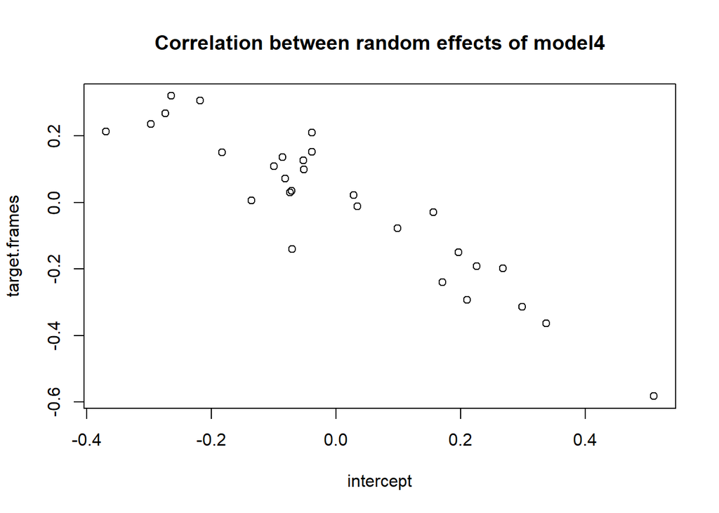

```r
#Model 4 is chosen since it performs better across different parameters of the likelihood ratio test as seen in the output of the anova() function. For example, model 4 is significantly different from model 3 (χ2(2)=346.41, p<0.05). Also, model 4 has the lowest AIC score, indicative it is a better model fit. Since model 4 is significantly different from model 3, and model 3 from model 2, model 2 from model 1, it is argued that the addition of predictor variables results in a better model fit.


#We now assess whether we should include the correlation between the random intercepts and slopes (with recourse to model4, since this was the best model).

lol <- ranef(model4)

for (i in seq(lol)){
  assign(paste0("lol", i), lol[[i]])
}

colnames(lol1) <- c("Intercept", "target.frames")

#We now plot the correlation between the random effects of intercept and slope.
plot(lol1$Intercept, lol1$target.frames, ylab="target.frames", xlab="intercept", main="Correlation between random effects of model4")
```